# Example Hypothesis Testing

Nicolas Stern

30 décembre 2018

# Hypothesis testing

- How to test a two-sided hypothesis based on sample data.
- Source : https://www.youtube.com/watch?v=vw2IPZ2aD-c
- Given the following values, let’s calculate the test value using t-statistics to assess our hypothesis:
  - H$_{0}$ : $\mu$ = 100
  - H$_{a}$ : $\mu$ != 100

```r
xbar <- 104 # sample mean
mu <- 100 # hypothetical population mean
n <- 35 # sample size
s <- 12 # sample standard deviation

# Calculate the test value
t <- (xbar - mu) / (s / sqrt(n))
t
```

```
## [1] 1.972027
```

We use a t-distribution, NOT the normal distribution, since we are working with sample data.

T-distribution is different from the normal distribution (although only very slightly). Let’s compare both curves. For the t-distribution, we use a value of 34 degrees of freedom (n-1):

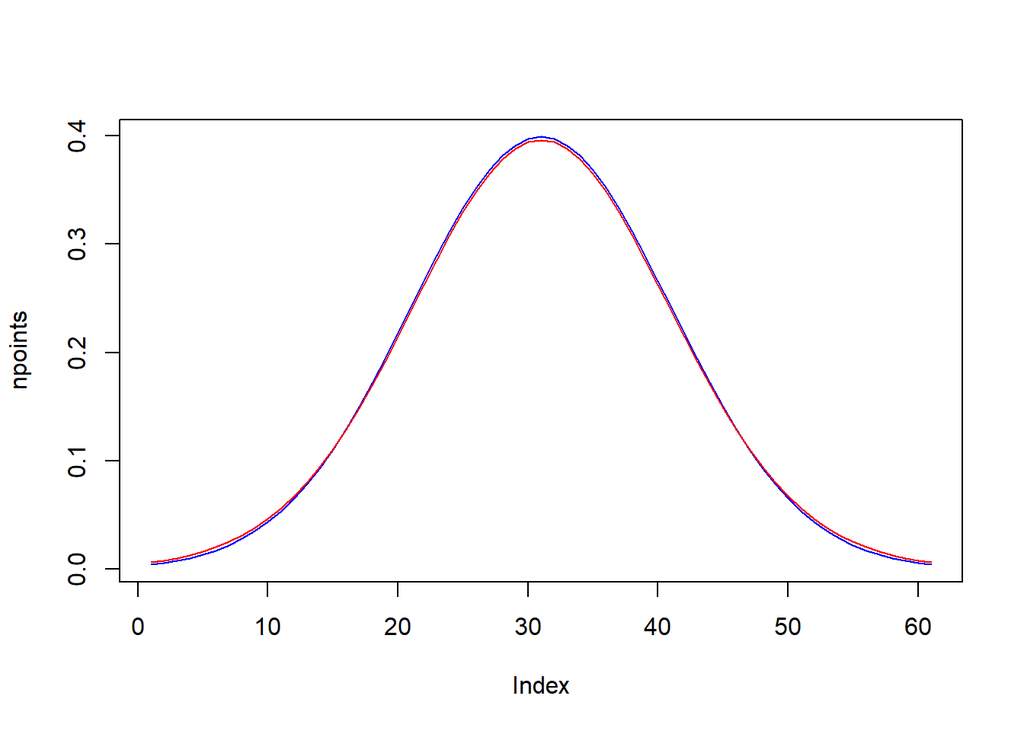

```r
ndata <- seq(-3, 3, by=0.1)
npoints <- dnorm(ndata)
tpoints <- dt(ndata, df=34)
plot(npoints, type="l", col="blue")
lines(tpoints, col="red")
```

Let’s further examine this difference : let’s calculate the probabilities using the t-distribution for the given t-value:

probability using the t-distribution:

```r
pt(t, df=n-1, lower.tail = F) * 2
```

```
## [1] 0.05678589
```

We multiplicate by 2 to cover the total area on the right of the t-value, AND on the left of -t-value.

Compare it with the normal distribution:

```r
pnorm(t, lower.tail = F) * 2
```

```
## [1] 0.04860657
```

Now, using the t-distribution, let’s examinate our hypothesis. We will reject H$_{0}$ if the t-value we calculated (1.9720266) is greater than a critical value (on the right side) or smaller (on the left side).

Let’s calculate the critical value for a 5 % significance level:

```r
alpha <- 0.05
talpha <- qt(1-alpha/2, df = n-1, lower.tail = T)
talpha
```

```
## [1] 2.032245
```

Since the t-value is smaller than the critical value, we have no evidence against H$_{0}$.

```r
p.value <- pt(t, df=24, lower.tail = F) * 2
p.value
```

```
## [1] 0.06023734
```

```r
p.value > alpha
```

```
## [1] TRUE
```

Since the p-value is greater than alpha, the evidence against H$_{0}$ is not significant.